# pcl_interobserver_test_nmnh

Amy Anderson

10/15/2019

still need to look up again how to stop Rmd from printing out all the sausage-making….

```r
knitr::opts_chunk$set(echo = TRUE, message = FALSE)
```

This script is intended to compare results of pathology assessment of porous cranial lesions from multiple viewing modalities ( 1) direct observation, 2)photos and 3) CT scans) by 3 separate observers.

In it I calculate percent agreement (within-modality across observers, and within-observer across modalities)

Data are the work of Anderson, Sutherland, and Campbell (2019). CT scans from which the data are drawn are courtesy of Dave Hunt and the Smithsonian National Museum of Natural History, and the Tsimane Health and Life History Project in collaboration with the Horus Group.

#### Load in the data files:

- anonymization key (so that observers do not connect cranium ID from photos to cranium ID when viewing scans)
- Anderson’s direct observation scores
- Anderson’s photo scores
- Campbell’s photo scores
- Sutherland’s photo scores
- Anderson’s scan scores
- Campbell’s scan scores
- Sutherland’s scan scores

## Data Wrangling

I want to combine all scores into a single data frame. For tidy data, I need an ‘observer’ column and a ‘modality’ column. For most IRR analyses I want binary presence/absence data.

1. Clean names across multiple spreadsheets
2. Mutate:
- create an ‘observer’ variable
- create a variable for each modality frame specifying modality (photo, 2d etc.)
3. Make data long: gather modality variables (2d, 3d, photo, direct) into one ‘modality’ column
4. Combine data frames by merging on cranial ID
5. Mutate: create a binary presence/absence score

#### Clean/wrangle Anonymization Key, *Anderson’s Direct Observation data*

```r
## Anonymization key.
anon_key <- anon_key %>%
  filter(anonymized_id != "H") %>% # remove erroneous "H" designation (refers to nothing)
rename(cranium_id = anonymized_id) %>%
  mutate(nmnh_id = as.character(nmnh_id))
```

#### Clean and wrangle Anderson’s data: Direct observations

```r
## Direct observation scores (Anderson)
aa_direct_wide <-aa_direct %>%
  rename(nmnh_id = specimen_no,
          orbit_score_direct = orbit_score,
         vault_score_direct = vault_score) %>%
  mutate(nmnh_id = as.character(nmnh_id)) %>%
  select(nmnh_id,
  orbit_score_direct,
  vault_score_direct) %>%
  mutate(orbit_direct_binary = if_else(orbit_score_direct > 0, 1, 0),
          vault_direct_binary = if_else(orbit_score_direct > 0, 1, 0))
```

#### Clean/wrangle *Anderson’s Photo data*

```r
##
aa_photos_wide <- aa_photos %>%
  filter(cranium_id != "H") %>%
  rename(vault_score_photo = vault_score) %>%
 mutate(orbit_score_photo = replace_na(orbit_score, 0)) %>%
 select(-orbit_score) %>%
 inner_join(anon_key) %>%
 mutate(orbit_photo_binary = if_else(orbit_score_photo > 0, 1, 0),
          vault_photo_binary = if_else(orbit_score_photo > 0, 1, 0))
```

#### Clean and wrangle Anderson’s Scan data

```r
## Anderson's scores from scans
aa_scans_wide <- aa_scans %>%
  mutate(nmnh_id = as.character(cranium_id)) %>% # numeric museum catalog ID is parsed as a numeric. Change that.
  rename(orbit_score_scan = rinaldo_score_co,
         vault_score_scan = rinaldo_score_ph,
         vault_scan_binary = x3d_ph_visible,
         orbit_scan_binary = x3d_co_visible,
         ecto_pitting = x2d_ectocranial_pitting,
         vault_2d_porosity = x2d_calvarial_surface_discontinuity,
         orbit_2d_porosity = x2d_orbital_roof_discontinuity,
         hair_on_end = x2d_radial_diploe) %>%
  select(nmnh_id,
          orbit_score_scan,
          vault_score_scan,
          vault_scan_binary,
          orbit_scan_binary,
          ecto_pitting,
          vault_2d_porosity,
          orbit_2d_porosity,
          hair_on_end)
```

Join Anderson data from all viewing modalities:

```r
anderson <- aa_direct_wide %>%
inner_join(aa_photos_wide) %>%
inner_join(aa_scans_wide) %>%
select(-cranium_id)


## Create presence/absence data frame for orbital scores
anderson_orbit_binary <- anderson %>%
select(orbit_direct_binary,
        orbit_photo_binary,
        orbit_scan_binary, # 3D visibility of lesions
        orbit_2d_porosity) # 2D visibility of porosity in orbits


## Create presence/absence data frame for vault scores
anderson_vault_binary <- anderson %>%
select(vault_direct_binary,
        vault_photo_binary,
        vault_scan_binary,
        vault_2d_porosity,
        ecto_pitting,
        hair_on_end) %>%
# create a 'combined porosity' variable that includes ectocranial pitting OR true porosity
        mutate(combo_porosity = if_else(ecto_pitting == 1, 1,
          if_else(vault_2d_porosity == 1, 1, 0)))
```

Now done wrangling Anderson’s observations (Observer 1). Moving on to Cambpell (Observer 2).

#### Clean and wrangle data from *Campbell’s observations: Photos and Scans*

```r
## clean and filter Campbell scan observations to merge with photo data
gc_photos <- gc_photos %>%
mutate(modality = "photo")


gc_scores <- gc_scans %>%
  rename("orbit_2d_porosity" = "x2d_orbital_marrow_width",
  "x2d_orbital_marrow_width" =  "x2d_orbital_roof_discontinuity",
# data entry for these two variables was clearly switched in the raw data file
  orbit_score_scan = rinaldo_score_co,
  vault_score_scan = rinaldo_score_ph,
  vault_scan_binary = x3d_ph_visible,
  orbit_scan_binary = x3d_co_visible,
  ecto_pitting = x2d_ectocranial_pitting,
  vault_2d_porosity = x2d_calvarial_surface_discontinuity,
  hair_on_end = x2d_radial_diploe) %>%
  mutate(nmnh_id = as.character(x0),
         observer = "gc",
         orbit_score_direct = NA, # populate this variable to prep for merging with Anderson data
         vault_score_direct = NA) %>%
# connect anonymization key
  inner_join(anon_key) %>%
# add photo scores
  inner_join(gc_photos) %>%
# consistent naming structure: anatomical area_score_modality
  rename(orbit_score_photo = orbit_photo_score,
         vault_score_photo = vault_photo_score) %>%
  mutate(orbit_photo_binary = if_else(orbit_score_photo > 0, 1, 0),
         vault_photo_binary = if_else(vault_score_photo > 0, 1, 0)) %>%
    select(nmnh_id,
          orbit_score_photo,
          vault_score_photo,
          orbit_photo_binary,
          vault_photo_binary,
          orbit_score_scan,
          vault_score_scan,
          vault_scan_binary,
          orbit_scan_binary,
          ecto_pitting,
          vault_2d_porosity,
          orbit_2d_porosity,
          hair_on_end) %>%
  # create a 'combined porosity' variable that includes ectocranial pitting OR true porosity
        mutate(combo_porosity = if_else(ecto_pitting == 1, 1,
          if_else(vault_2d_porosity == 1, 1, 0))
          )
```

#### Clean and Wrangle *Sutherland’s photo and scan data*:

```r
## Sutherland photo data (scan data coming shortly)
ls_photos_tidy <- ls_photos%>%
  filter(cranium != "h") %>%
  rename(cranium_id = cranium,
         vault_score_photo = ph_rinaldo_score,
         orbit_score_photo = co_rinaldo_score) %>%
  mutate(cranium_id = toupper(cranium_id),
         modality = "photo",
         observer = "ls") %>%
   inner_join(anon_key) %>%
  pivot_longer(cols = c(vault_score_photo,
                        orbit_score_photo),
               names_to = "criterion",
               values_to = "score") %>%
  # create binary presence/absence version of all criteria scores
  mutate(binary_score = if_else(score >= 1, 1, 0))

#mutate(vault_photo_binary = if_else(vault_photo_score > 0, 1, 0),
        # orbit_photo_binary = if_else(orbit_photo_score >= 1, 1, 0)) %>%# REMEMBER!!! lots of NA's (missing photos) get turned to zeros here: don't analyze orbital data yet. % Agreement will be artificially inflated.
# BUT the NAs are being turned to 1's and I don't understand why....
```

```r
## set up a matrix (ncol(anderson_orbit_binary) x ncol(anderson_orbit_binary)) filled with NAs to create a space for the for loop to populate.
aa_orbit_irr <- matrix(NA, ncol = 4, nrow = 4)
# assign names to the matrix rows and columns
rownames(aa_orbit_irr) <- c("direct obs",
                            "photo",
                            "3D CT",
                            "2D CT")
colnames(aa_orbit_irr) <- rownames(aa_orbit_irr)


## BEHOLD, a nested for loop that iterates the agree() function over each pairwise combination of columns in the orbit presence/absence data

# Anderson Orbit scores
for(i in 1:ncol(anderson_orbit_binary)){
  for(j in 1:ncol(anderson_orbit_binary)){
  if(i == j) 0
   aa_orbit_irr[i,j] <- (agree(anderson_orbit_binary[,c(i,j)])$value / 100)
  }
}
```

… And again for Anderson Vault scores

```r
aa_vault_irr <- matrix(NA, ncol = 7, nrow = 7)
# assign names to the matrix rows and columns
rownames(aa_vault_irr) <- c("direct obs",
                            "photo",
                            "3D CT",
                            "2D CT - porosity",
                            "2D CT - pitting",
                            "2d CT porosity/pitting",
                            "hair-on-end sign")
colnames(aa_vault_irr) <- rownames(aa_vault_irr)


# Anderson Vault scores
for(i in 1:ncol(anderson_vault_binary)){
  for(j in 1:ncol(anderson_vault_binary)){
  if(i == j) 0
   aa_vault_irr[i,j] <- agree(anderson_vault_binary[,c(i,j)])$value / 100
  }
}
```

Create two heatmap correlation tables of Anderson’s intraobserver agreement (1. orbits, 2. vaults)

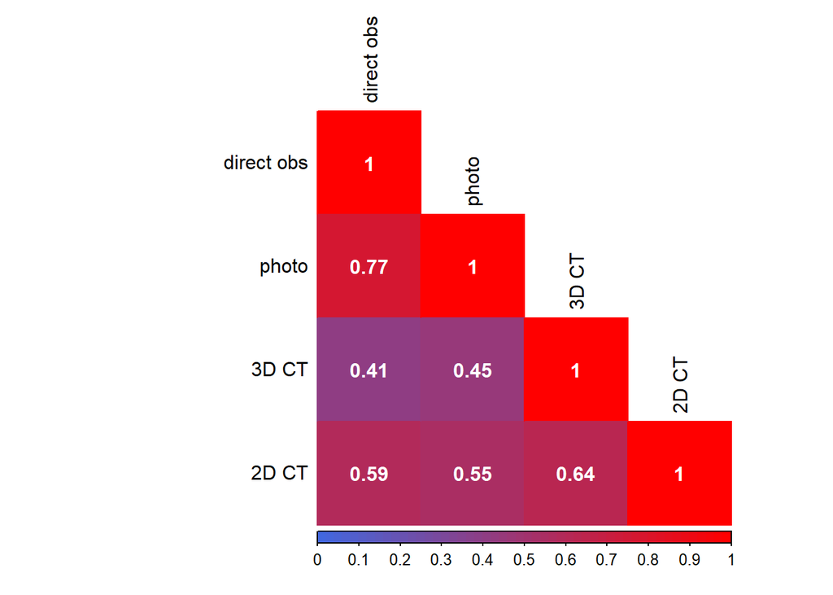

```r
## for orbits
orbit_corrplot_aa <- corrplot(corr = aa_orbit_irr,
                            method = "color",
                            type = "lower",
                     col = colorRampPalette(c("green", "royal blue","red"))(100),
                     diag = TRUE,
                     addCoef.col = "white",
                     tl.col = "black",
                     cl.lim = c(0,1))
```

[figure not shown]

```r
## and for vaults
vault_corrplot_aa <- corrplot(corr = aa_vault_irr,
                            method = "color",
                            type = "lower",
                     col = colorRampPalette(c("green", "royal blue","red"))(100),
                     diag = TRUE,
                     addCoef.col = "white",
                     tl.col = "black",
                     cl.lim = c(0,1))
```

All right, now that you’ve managed intra-observer % agreement for Anderson, do it all over again for Campbell

```r
## create binary data frame for orbit scores
campbell_orbit_binary <- gc_scores %>%
select(orbit_photo_binary,
        orbit_scan_binary, # 3D visibility of lesions
        orbit_2d_porosity) # 2D visibility of porosity in orbits


## and create binary data frame for vault scores
campbell_vault_binary <- gc_scores %>%
select(vault_photo_binary,
        vault_scan_binary,
        vault_2d_porosity,
        ecto_pitting,
        combo_porosity,
        hair_on_end)
```

Time for a for loop to iterate %A

```r
## set up a matrix (ncol(campbell_orbit_binary) x ncol(campbelln_orbit_binary)) filled with NAs to create a space for the for loop to populate.
gc_orbit_irr <- matrix(NA, ncol = 3, nrow = 3)
# assign names to the matrix rows and columns
rownames(gc_orbit_irr) <- c("photo",
                            "3D CT",
                            "2D CT")
colnames(gc_orbit_irr) <- rownames(gc_orbit_irr)


## and now, a nested for loop that iterates the agree() function over each pairwise combination of columns in the orbit presence/absence data

# Campbell Orbit scores
for(i in 1:ncol(campbell_orbit_binary)){
  for(j in 1:ncol(campbell_orbit_binary)){
  if(i == j) 0
   gc_orbit_irr[i,j] <- (agree(campbell_orbit_binary[,c(i,j)])$value / 100)
    }
}


## Campbell intra-observer agreement, vault scores
gc_vault_irr <- matrix(NA, ncol = 6, nrow = 6)
# assign names to the matrix rows and columns
rownames(gc_vault_irr) <- c("photo",
                            "3D CT",
                            "2D CT - porosity",
                            "2D CT - pitting",
                            "2d CT porosity/pitting",
                            "hair-on-end sign")
colnames(gc_vault_irr) <- rownames(gc_vault_irr)

# for loop for agree() for Campbell's vault observations across modalities
for(i in 1:ncol(campbell_vault_binary)){
  for(j in 1:ncol(campbell_vault_binary)){
  if(i == j) 0
   gc_vault_irr[i,j] <- (agree(campbell_vault_binary[,c(i,j)])$value / 100)
    }
}
```

Corrplot heatmap tables of Campbell’s intra-observer agreement:

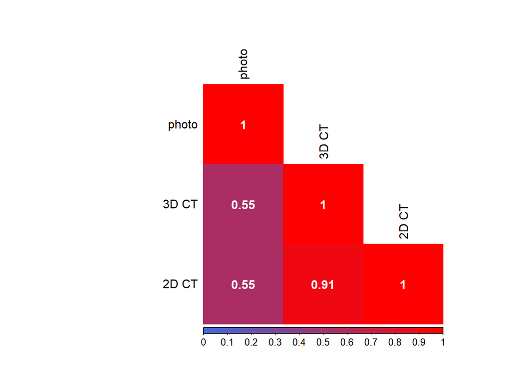

```r
## for orbits
orbit_corrplot_gc <- corrplot(corr = gc_orbit_irr,
                            method = "color",
                            type = "lower",
                     col = colorRampPalette(c("green", "royal blue","red"))(100),
                     diag = TRUE,
                     addCoef.col = "white",
                     tl.col = "black",
                     cl.lim = c(0,1))
```

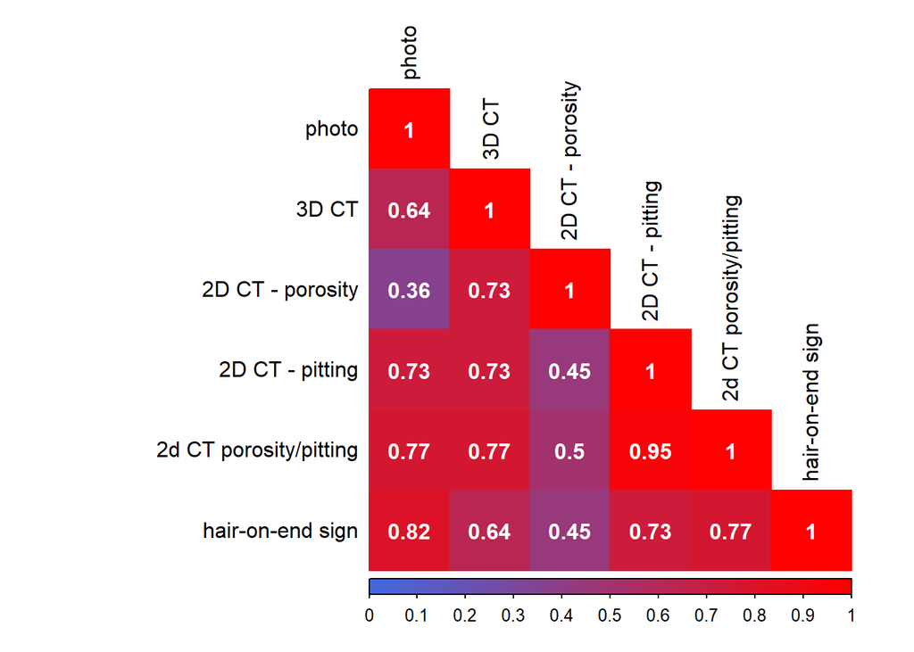

```r
## and for vaults
vault_corrplot_gc <- corrplot(corr = gc_vault_irr,
                            method = "color",
                            type = "lower",
                     col = colorRampPalette(c("green", "royal blue","red"))(100),
                     diag = TRUE,
                     addCoef.col = "white",
                     tl.col = "black",
                     cl.lim = c(0,1))
```

rater.bias() function in the irr package will calculate systematic bias between two observers. <– use this!

Presence/Absence IRR can be calculated for pairs of observers (Cohen’s kappa, unweighted) or across multiple observers (Fleiss’s kappa).

IRR of ordinal scores can only be calculated for pairs of observers, using a weighted Cohen’s kappa

```r
# Cohen's k for orbit photo scores (presence/absence)
```